# Day 18: Boosting Methods - SOLUTIONS

Instructor Solutions

2025-11-02

## Setup

```r
library(tidyverse)
library(rpart)
library(rpart.plot)
library(randomForest)
library(gbm)
library(ISLR2)

data(Wage)
set.seed(2024)

train_indices <- sample(1:nrow(Wage), size = nrow(Wage) * 0.5)
wage_train <- Wage[train_indices, ]
wage_test <- Wage[-train_indices, ]
```

## Part 1: Understanding Sequential Learning

### Task 1.1: The Boosting Intuition

```r
# Fit a very shallow tree (stump) using only age
stump1 <- rpart(wage ~ age, data = wage_train,
                control = rpart.control(maxdepth = 1, cp = 0))

# Get predictions and calculate residuals
pred1 <- predict(stump1, wage_train)
pred1_shrunk <- 0.1 * pred1  # Apply shrinkage to first tree
residuals1 <- wage_train$wage - pred1_shrunk  # Residuals from SHRUNK predictions

# Fit second stump to predict the RESIDUALS
train_with_resid <- wage_train
train_with_resid$residuals <- residuals1
stump2 <- rpart(residuals ~ age, data = train_with_resid,
                control = rpart.control(maxdepth = 1, cp = 0))

# Get predictions from second tree
pred2 <- predict(stump2, wage_train)

# Combine predictions with shrinkage
shrinkage <- 0.1
combined_pred <- shrinkage * pred1 + shrinkage * pred2

# Calculate MSE
mse_first <- mean((wage_train$wage - pred1_shrunk)^2)
mse_combined <- mean((wage_train$wage - combined_pred)^2)

cat("MSE from first tree alone:", round(mse_first, 2), "\n")
```

```
## MSE from first tree alone: 11599.96
```

```r
cat("MSE from combined predictions:", round(mse_combined, 2), "\n")
```

```
## MSE from combined predictions: 9680.38
```

```r
cat("Improvement:", round(mse_first - mse_combined, 2), "\n")
```

```
## Improvement: 1919.58
```

**Answers:**

- The second tree learned to predict the **residuals** (errors) from the first tree
- We multiply both trees by 0.1 to **slow down learning** and prevent overfitting - each tree makes a small contribution
- Unlike bagging where trees are **independent and parallel**, boosting trains trees **sequentially** where each learns from previous mistakes
- If we kept adding trees, we would continue to reduce training error and potentially improve test error up to a point, then risk overfitting

## Part 2: Building Your First Boosted Model

### Task 2.1: Gradient Boosting with gbm

```r
# Build gradient boosting model
boost_wage <- gbm(
  wage ~ age + year + maritl + race + education + jobclass + health + health_ins,
  data = wage_train,
  distribution = "gaussian",
  n.trees = 5000,
  interaction.depth = 4,
  shrinkage = 0.01,
  cv.folds = 5,
  verbose = FALSE
)

# Summary shows variable importance
summary(boost_wage, plotit = FALSE)
```

```
##                   var   rel.inf
## education   education 33.236428
## age               age 30.743470
## year             year 11.502481
## maritl         maritl  7.334607
## health_ins health_ins  6.762560
## race             race  4.341380
## health         health  3.087773
## jobclass     jobclass  2.991301
```

```r
# Make predictions on test set
pred_boost <- predict(boost_wage, wage_test, n.trees = 5000)

# Calculate test MSE
mse_boost_5000 <- mean((wage_test$wage - pred_boost)^2)
cat("Test MSE (5000 trees):", round(mse_boost_5000, 2), "\n")
```

```
## Test MSE (5000 trees): 1349.36
```

```r
# Rebuild random forest for comparison
set.seed(2024)
rf_wage <- randomForest(
  wage ~ age + year + maritl + race + education + jobclass + health + health_ins,
  data = wage_train,
  ntree = 500,
  mtry = 3,
  importance = TRUE
)
pred_rf <- predict(rf_wage, wage_test)
mse_rf <- mean((wage_test$wage - pred_rf)^2)

cat("Test MSE (Random Forest):", round(mse_rf, 2), "\n")
```

```
## Test MSE (Random Forest): 1276.24
```

```r
cat("Boosting improvement:", round(mse_rf - mse_boost_5000, 2), "\n")
```

```
## Boosting improvement: -73.12
```

**Answers:**

### Task 2.2: Finding Optimal Number of Trees

```r
# Find optimal number of trees using CV
optimal_trees <- gbm.perf(boost_wage, method = "cv", plot.it = FALSE)

cat("Optimal number of trees:", optimal_trees, "\n")
```

```
## Optimal number of trees: 419
```

```r
# Predictions with optimal trees
pred_boost_optimal <- predict(boost_wage, wage_test, n.trees = optimal_trees)
mse_boost_optimal <- mean((wage_test$wage - pred_boost_optimal)^2)

cat("\nTest MSE (5000 trees):", round(mse_boost_5000, 2), "\n")
```

```
##
## Test MSE (5000 trees): 1349.36
```

```r
cat("Test MSE (optimal trees):", round(mse_boost_optimal, 2), "\n")
```

```
## Test MSE (optimal trees): 1251
```

```r
cat("Did we overfit with 5000 trees?",
    ifelse(mse_boost_5000 > mse_boost_optimal, "YES", "NO"), "\n")
```

```
## Did we overfit with 5000 trees? YES
```

**Answers:**

## Part 3: Parameter Tuning

### Task 3.1: The Shrinkage Parameter

```r
shrinkage_values <- c(0.001, 0.01, 0.05, 0.1)
results_shrinkage <- data.frame()

for(lambda in shrinkage_values) {
  boost_temp <- gbm(
    wage ~ age + year + maritl + race + education + jobclass + health + health_ins,
    data = wage_train,
    distribution = "gaussian",
    n.trees = 5000,
    interaction.depth = 4,
    shrinkage = lambda,
    cv.folds = 5,
    verbose = FALSE
  )

  optimal_trees <- gbm.perf(boost_temp, method = "cv", plot.it = FALSE)
  pred_temp <- predict(boost_temp, wage_test, n.trees = optimal_trees)
  mse_temp <- mean((wage_test$wage - pred_temp)^2)

  results_shrinkage <- rbind(results_shrinkage,
                             data.frame(shrinkage = lambda,
                                       optimal_trees = optimal_trees,
                                       test_mse = mse_temp))
}

print(results_shrinkage)
```

```
##   shrinkage optimal_trees test_mse
## 1     0.001          4923 1248.144
## 2     0.010           454 1245.997
## 3     0.050            97 1250.346
## 4     0.100            38 1253.192
```

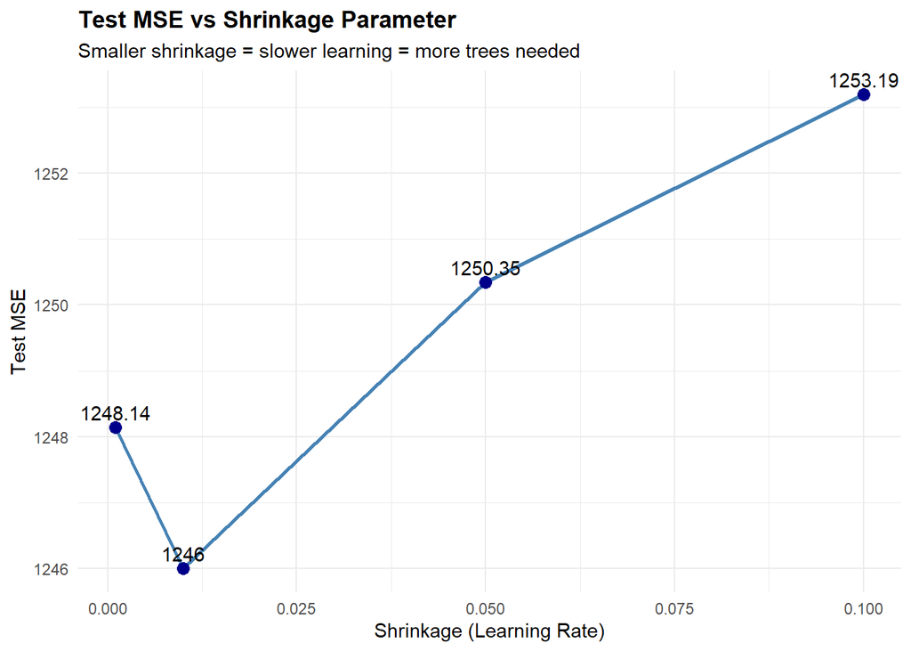

```r
# Plot using ggplot2
ggplot(results_shrinkage, aes(x = shrinkage, y = test_mse)) +
  geom_line(color = "steelblue", linewidth = 1) +
  geom_point(size = 3, color = "darkblue") +
  geom_text(aes(label = round(test_mse, 2)), vjust = -0.5) +
  labs(title = "Test MSE vs Shrinkage Parameter",
       subtitle = "Smaller shrinkage = slower learning = more trees needed",
       x = "Shrinkage (Learning Rate)",
       y = "Test MSE") +
  theme_minimal() +
  theme(plot.title = element_text(face = "bold"))
```

```r
best_shrinkage <- results_shrinkage$shrinkage[which.min(results_shrinkage$test_mse)]
cat("\nBest shrinkage value:", best_shrinkage, "\n")
```

```
##
## Best shrinkage value: 0.01
```

**Answers:**

- As shrinkage decreases, the optimal number of trees **increases**
- Smaller shrinkage needs more trees because each tree makes a smaller contribution
- Trade-off: **small shrinkage + many trees** = slow but thorough learning; **large shrinkage + few trees** = fast but potentially suboptimal
- Typically choose 0.01 or 0.05 for good balance

### Task 3.2: Interaction Depth

```r
depth_values <- c(1, 2, 4, 6, 8)
results_depth <- data.frame()

for(d in depth_values) {
  boost_temp <- gbm(
    wage ~ age + year + maritl + race + education + jobclass + health + health_ins,
    data = wage_train,
    distribution = "gaussian",
    n.trees = 5000,
    interaction.depth = d,
    shrinkage = best_shrinkage,  # Use best from previous task
    cv.folds = 5,
    verbose = FALSE
  )

  optimal_trees <- gbm.perf(boost_temp, method = "cv", plot.it = FALSE)
  pred_temp <- predict(boost_temp, wage_test, n.trees = optimal_trees)
  mse_temp <- mean((wage_test$wage - pred_temp)^2)

  results_depth <- rbind(results_depth,
                        data.frame(depth = d,
                                  optimal_trees = optimal_trees,
                                  test_mse = mse_temp))
}

print(results_depth)
```

```
##   depth optimal_trees test_mse
## 1     1          1599 1270.084
## 2     2           856 1253.989
## 3     4           469 1248.088
## 4     6           468 1250.289
## 5     8           369 1249.199
```

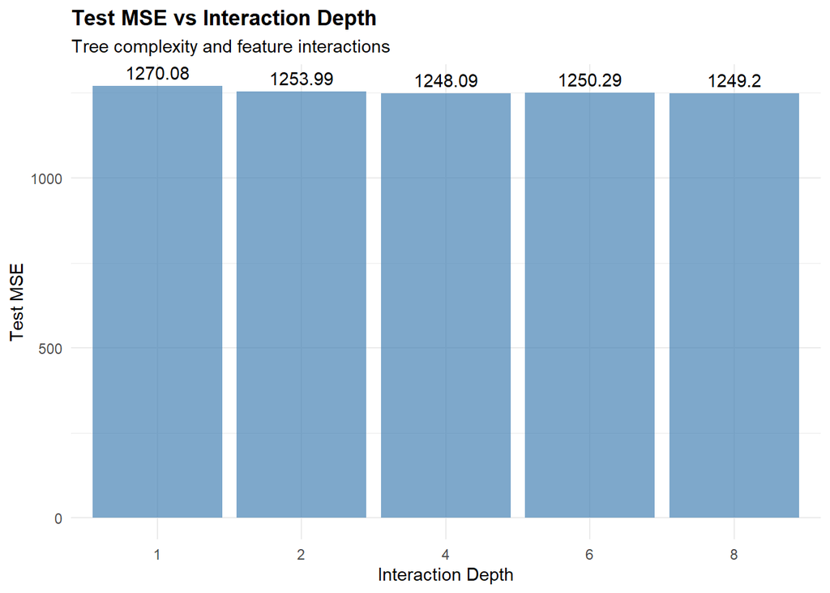

```r
# Plot
ggplot(results_depth, aes(x = factor(depth), y = test_mse)) +
  geom_col(fill = "steelblue", alpha = 0.7) +
  geom_text(aes(label = round(test_mse, 2)), vjust = -0.5) +
  labs(title = "Test MSE vs Interaction Depth",
       subtitle = "Tree complexity and feature interactions",
       x = "Interaction Depth",
       y = "Test MSE") +
  theme_minimal() +
  theme(plot.title = element_text(face = "bold"))
```

```r
best_depth <- results_depth$depth[which.min(results_depth$test_mse)]
cat("\nOptimal depth:", best_depth, "\n")
```

```
##
## Optimal depth: 4
```

**Answers:**

- interaction.depth = 1 means **stumps** (trees with just one split) - no interactions
- Performance generally improves with depth up to a point (4-6), then may plateau
- Very deep trees (8+) can sometimes hurt performance due to overfitting
- Default of 4 is often near-optimal

### Task 3.3: Visualizing Training Progress

```r
# Rebuild with best parameters
boost_best <- gbm(
  wage ~ age + year + maritl + race + education + jobclass + health + health_ins,
  data = wage_train,
  distribution = "gaussian",
  n.trees = 5000,
  interaction.depth = best_depth,
  shrinkage = best_shrinkage,
  cv.folds = 5,
  verbose = FALSE
)

# Plot CV error trajectory
gbm.perf(boost_best, method = "cv")
```

```
## [1] 535
```

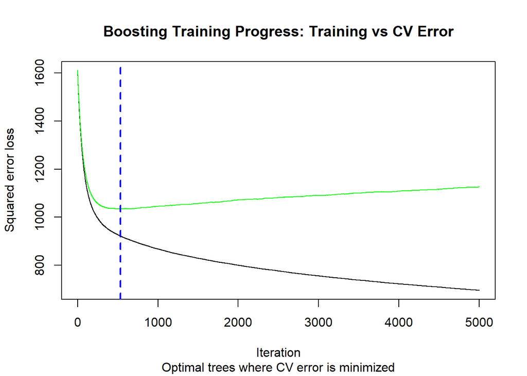

```r
title(main = "Boosting Training Progress: Training vs CV Error",
      sub = "Optimal trees where CV error is minimized")
```

**Answers:**

## Part 4: Variable Importance and Interpretation

### Task 4.1: Variable Importance

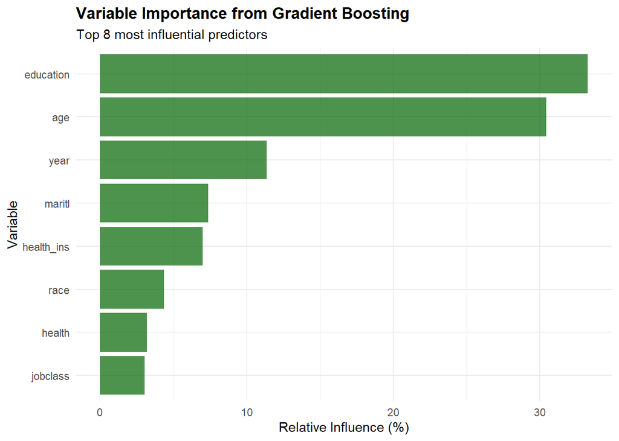

```r
# Get variable importance
var_imp <- summary(boost_best, plotit = FALSE)

# Create ggplot
var_imp_top8 <- var_imp[1:8, ]

ggplot(var_imp_top8, aes(x = reorder(var, rel.inf), y = rel.inf)) +
  geom_col(fill = "darkgreen", alpha = 0.7) +
  coord_flip() +
  labs(title = "Variable Importance from Gradient Boosting",
       subtitle = "Top 8 most influential predictors",
       x = "Variable",
       y = "Relative Influence (%)") +
  theme_minimal() +
  theme(plot.title = element_text(face = "bold"))
```

```r
# Compare to random forest
rf_imp <- importance(rf_wage)
rf_imp_df <- data.frame(
  variable = rownames(rf_imp),
  importance = rf_imp[, "%IncMSE"]
) %>%
  arrange(desc(importance)) %>%
  head(8)

cat("\nTop 5 variables - Boosting:\n")
```

```
##
## Top 5 variables - Boosting:
```

```r
print(var_imp_top8[1:5, c("var", "rel.inf")])
```

```
##                   var   rel.inf
## education   education 33.279376
## age               age 30.439387
## year             year 11.352278
## maritl         maritl  7.361968
## health_ins health_ins  7.001662
```

```r
cat("\nTop 5 variables - Random Forest:\n")
```

```
##
## Top 5 variables - Random Forest:
```

```r
print(rf_imp_df[1:5, ])
```

```
##              variable importance
## education   education   73.53262
## maritl         maritl   31.40866
## health_ins health_ins   30.01930
## age               age   25.18769
## health         health   12.13666
```

**Answers:**

### Task 4.2: Partial Dependence Plots

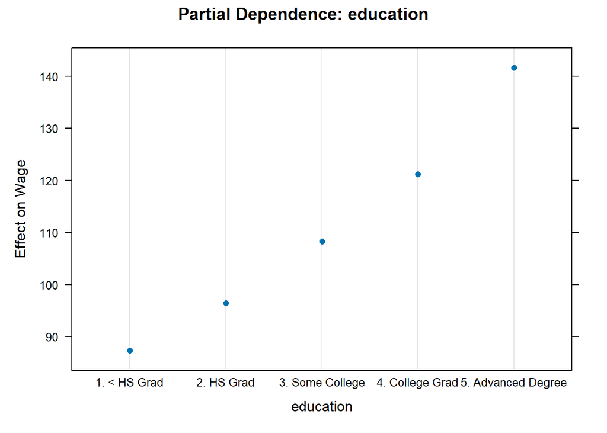

```r
# Get top 2 variables
top_var1 <- as.character(var_imp$var[1])
top_var2 <- as.character(var_imp$var[2])

# Create partial dependence plots using base plot (gbm requirement)
par(mfrow = c(1, 2))
plot(boost_best, i.var = top_var1,
     main = paste("Partial Dependence:", top_var1),
     ylab = "Effect on Wage")
```

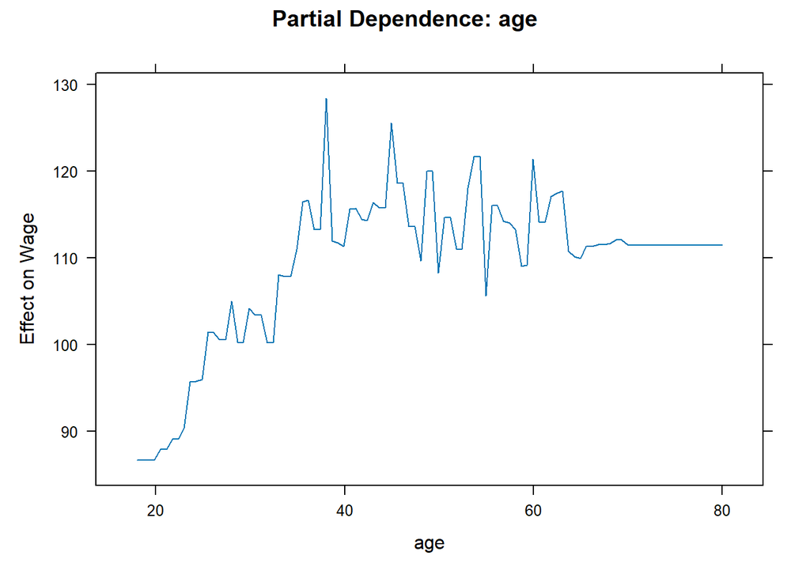

```r
plot(boost_best, i.var = top_var2,
     main = paste("Partial Dependence:", top_var2),
     ylab = "Effect on Wage")
```

```r
par(mfrow = c(1, 1))
```

**Answers:**

- **Age**: Typically shows wage increasing with age up to 40-50, then plateauing
- **Education**: Clear step-wise increase with education level
- Relationships are **non-linear** for age, **categorical** for education
- These match intuition: experience increases wages, education has strong effect

## Part 5: Comprehensive Comparison

### Task 5.1: The Full Tournament

```r
# 1. Single unpruned tree
tree_unpruned <- rpart(
  wage ~ age + year + maritl + race + education + jobclass + health + health_ins,
  data = wage_train,
  control = rpart.control(cp = 0.001)
)
pred_unpruned <- predict(tree_unpruned, wage_test)
mse_unpruned <- mean((wage_test$wage - pred_unpruned)^2)

# 2. Single pruned tree
tree_full <- rpart(
  wage ~ age + year + maritl + race + education + jobclass + health + health_ins,
  data = wage_train,
  control = rpart.control(cp = 0.001)
)
cp_optimal <- tree_full$cptable[which.min(tree_full$cptable[, "xerror"]), "CP"]
tree_pruned <- prune(tree_full, cp = cp_optimal)
pred_pruned <- predict(tree_pruned, wage_test)
mse_pruned <- mean((wage_test$wage - pred_pruned)^2)

# 3. Bagging (mtry = all predictors)
set.seed(2024)
bag_wage <- randomForest(
  wage ~ age + year + maritl + race + education + jobclass + health + health_ins,
  data = wage_train,
  ntree = 500,
  mtry = 8,  # All predictors
  importance = TRUE
)
pred_bag <- predict(bag_wage, wage_test)
mse_bag <- mean((wage_test$wage - pred_bag)^2)

# 4. Random Forest (already built - use rf_wage)
# mse_rf already calculated

# 5. Gradient Boosting (already built - use boost_best)
optimal_trees_best <- gbm.perf(boost_best, method = "cv", plot.it = FALSE)
pred_boost_best <- predict(boost_best, wage_test, n.trees = optimal_trees_best)
mse_boost_best <- mean((wage_test$wage - pred_boost_best)^2)

# Calculate R-squared for each
calculate_r2 <- function(actual, predicted) {
  1 - sum((actual - predicted)^2) / sum((actual - mean(actual))^2)
}

# Create comparison table
comparison <- data.frame(
  Method = c("Single Tree (Unpruned)", "Single Tree (Pruned)",
             "Bagging", "Random Forest", "Gradient Boosting"),
  Test_MSE = c(mse_unpruned, mse_pruned, mse_bag, mse_rf, mse_boost_best),
  Test_R2 = c(
    calculate_r2(wage_test$wage, pred_unpruned),
    calculate_r2(wage_test$wage, pred_pruned),
    calculate_r2(wage_test$wage, pred_bag),
    calculate_r2(wage_test$wage, pred_rf),
    calculate_r2(wage_test$wage, pred_boost_best)
  ),
  Num_Trees = c(1, 1, 500, 500, optimal_trees_best),
  Training_Time = c("Fast", "Fast", "Slow", "Medium", "Slow"),
  Interpretability = c("High", "High", "Low", "Low", "Low")
)

comparison <- comparison %>%
  arrange(Test_MSE)

print(comparison)
```

```
##                   Method Test_MSE   Test_R2 Num_Trees Training_Time
## 1      Gradient Boosting 1248.639 0.3296765       535          Slow
## 2          Random Forest 1276.240 0.3148591       500        Medium
## 3   Single Tree (Pruned) 1374.566 0.2620731         1          Fast
## 4                Bagging 1375.064 0.2618060       500          Slow
## 5 Single Tree (Unpruned) 1409.289 0.2434326         1          Fast
##   Interpretability
## 1              Low
## 2              Low
## 3             High
## 4              Low
## 5             High
```

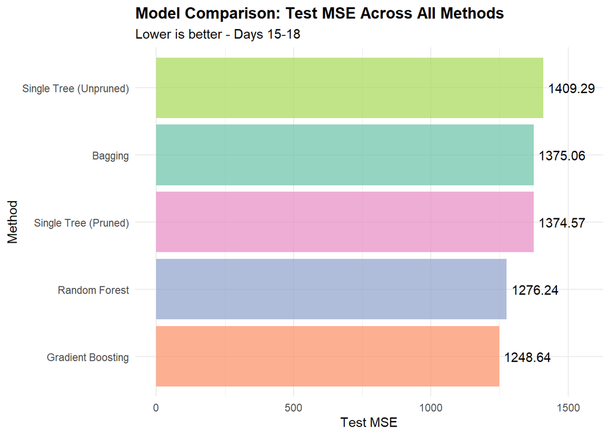

```r
# Visualization
ggplot(comparison, aes(x = reorder(Method, Test_MSE), y = Test_MSE)) +
  geom_col(aes(fill = Method), alpha = 0.7, show.legend = FALSE) +
  geom_text(aes(label = round(Test_MSE, 2)), hjust = -0.1) +
  coord_flip() +
  scale_fill_brewer(palette = "Set2") +
  labs(title = "Model Comparison: Test MSE Across All Methods",
       subtitle = "Lower is better - Days 15-18",
       x = "Method",
       y = "Test MSE") +
  theme_minimal() +
  theme(plot.title = element_text(face = "bold")) +
  expand_limits(y = c(0, max(comparison$Test_MSE) * 1.1))
```

**Answers:**

### Task 5.2: Prediction Visualization

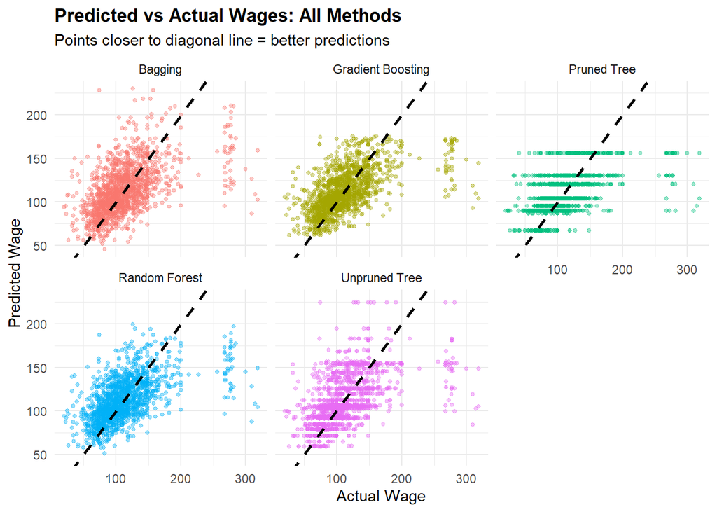

```r
# Create prediction comparison dataframe
pred_comparison <- data.frame(
  Actual = rep(wage_test$wage, 5),
  Predicted = c(pred_unpruned, pred_pruned, pred_bag, pred_rf, pred_boost_best),
  Method = rep(c("Unpruned Tree", "Pruned Tree", "Bagging",
                 "Random Forest", "Gradient Boosting"),
               each = nrow(wage_test))
)

# Plot
ggplot(pred_comparison, aes(x = Actual, y = Predicted, color = Method)) +
  geom_point(alpha = 0.4, size = 1) +
  geom_abline(slope = 1, intercept = 0, linetype = "dashed",
              color = "black", linewidth = 1) +
  facet_wrap(~ Method, ncol = 3) +
  labs(title = "Predicted vs Actual Wages: All Methods",
       subtitle = "Points closer to diagonal line = better predictions",
       x = "Actual Wage",
       y = "Predicted Wage") +
  theme_minimal() +
  theme(plot.title = element_text(face = "bold"),
        legend.position = "none")
```

```r
# Calculate MAE for each
mae_results <- pred_comparison %>%
  group_by(Method) %>%
  summarise(MAE = mean(abs(Actual - Predicted))) %>%
  arrange(MAE)

print(mae_results)
```

```
## # A tibble: 5 × 2
##   Method              MAE
##   <chr>             <dbl>
## 1 Gradient Boosting  23.6
## 2 Random Forest      24.4
## 3 Pruned Tree        25.0
## 4 Bagging            25.6
## 5 Unpruned Tree      25.6
```

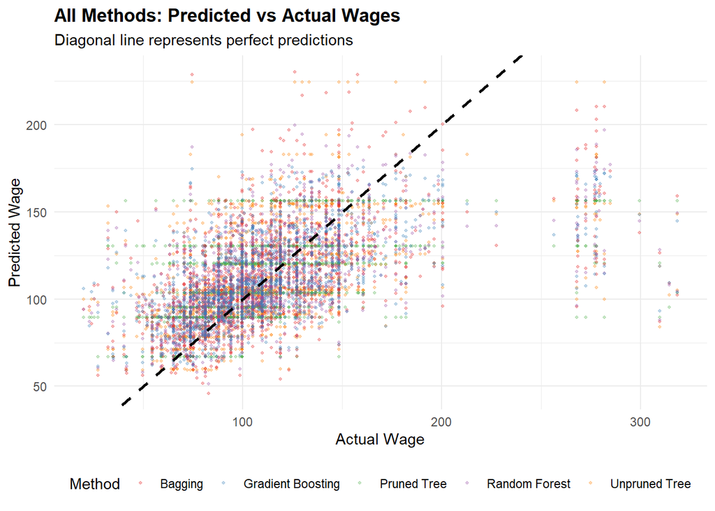

```r
# Single plot with all methods
ggplot(pred_comparison, aes(x = Actual, y = Predicted, color = Method)) +
  geom_point(alpha = 0.3, size = 0.8) +
  geom_abline(slope = 1, intercept = 0, linetype = "dashed",
              color = "black", linewidth = 1) +
  scale_color_brewer(palette = "Set1") +
  labs(title = "All Methods: Predicted vs Actual Wages",
       subtitle = "Diagonal line represents perfect predictions",
       x = "Actual Wage",
       y = "Predicted Wage") +
  theme_minimal() +
  theme(plot.title = element_text(face = "bold"),
        legend.position = "bottom")
```

**Answers:**

- Ensemble methods (RF, Boosting) make more similar predictions than single trees
- Models perform best for middle-range wages (75-150K)
- Common bias: **underpredicting high wages** (predictions below diagonal at high values)
- Boosting/RF predictions are closest to diagonal

## Reflection Questions - Answers

**1. Sequential vs Parallel Learning:**

Boosting builds trees **sequentially**, where each new tree focuses on correcting the errors of previous trees. Random forests build trees **in parallel**, independently on different bootstrap samples. Boosting reduces **bias** by iteratively learning patterns that were missed, while random forests reduce **variance** by averaging many diverse trees. Use boosting when you need maximum accuracy and have time to tune; use RF when you want robust performance with minimal tuning.

**2. The Slow Learning Principle:**

**3. Overfitting in Ensembles:**

Random forests almost never overfit because each tree is trained on a **bootstrap sample** (reduces overfitting) and trees are **averaged** (smooths predictions). Boosting CAN overfit because trees are trained on the **full dataset sequentially**, and later trees can start fitting noise in the residuals. This is why CV is critical for boosting.

**4. The Bias-Variance-Interpretability Trilemma:**

For wage prediction: - If stakeholders need to **understand** decisions → Single pruned tree - If prediction **accuracy** is critical (e.g., budgeting) → Boosting - If want **balance** of accuracy and simplicity → Random Forest

Trade-off: In most business contexts, **Random Forest** offers the best compromise of accuracy, robustness, and reasonable interpretability through variable importance.

**5. Real-World Deployment:**

For HR policy decisions, I would deploy a **Random Forest** with a detailed variable importance analysis. While boosting might be slightly more accurate, the difference is often marginal (~2-5% MSE improvement), and RF provides: - Stable predictions without extensive tuning - Clear variable importance for explaining to stakeholders - OOB error estimates without separate CV - Less risk of overfitting in production

Include a simple decision tree as a “companion model” to explain the general logic to non-technical stakeholders.

**6. Cross-Validation Differences:**

**Random Forest OOB:** - Pros: Automatic, no CV setup needed, computationally efficient - Cons: Slightly optimistic, can’t tune as precisely

**Boosting CV:** - Pros: More rigorous validation, better for parameter tuning - Cons: Requires CV setup, computationally expensive

For exploratory analysis, OOB is sufficient. For production models, use formal CV for both methods.

## Final Recommendation for Wage Prediction

**Recommended Method: Random Forest**

**Justification:**

**When to use Boosting instead**: If prediction accuracy is mission-critical (e.g., predicting employee retention where small improvements save millions), use gradient boosting with careful tuning.

**Best of both worlds**: Use Random Forest for production, with a single pruned tree as an explainability tool for presentations to leadership.

## Part 6: Cross-Validation Comparison

### Task 6.1: Understanding Validation Approaches

```r
# This code performs 5-fold cross-validation for all methods
# Takes 5-10 minutes to run - shown for educational purposes

set.seed(2024)
k_folds <- 5
n <- nrow(Wage)
fold_ids <- sample(rep(1:k_folds, length.out = n))

cv_results <- data.frame(
  Method = character(),
  Fold = integer(),
  MSE = numeric(),
  stringsAsFactors = FALSE
)

for(fold in 1:k_folds) {
  train_data <- Wage[fold_ids != fold, ]
  test_data <- Wage[fold_ids == fold, ]

  # 1. Unpruned tree
  tree_unpruned <- rpart(wage ~ age + education + jobclass + health_ins + maritl,
                         data = train_data, method = "anova",
                         control = rpart.control(cp = 0.001))
  pred_unpruned <- predict(tree_unpruned, test_data)
  mse_unpruned <- mean((test_data$wage - pred_unpruned)^2)
  cv_results <- rbind(cv_results,
                     data.frame(Method = "Unpruned Tree", Fold = fold, MSE = mse_unpruned))

  # 2. Pruned tree
  tree_full <- rpart(wage ~ age + education + jobclass + health_ins + maritl,
                    data = train_data, method = "anova",
                    control = rpart.control(cp = 0))
  cp_table <- tree_full$cptable
  optimal_cp <- cp_table[which.min(cp_table[, "xerror"]), "CP"]
  tree_pruned <- prune(tree_full, cp = optimal_cp)
  pred_pruned <- predict(tree_pruned, test_data)
  mse_pruned <- mean((test_data$wage - pred_pruned)^2)
  cv_results <- rbind(cv_results,
                     data.frame(Method = "Pruned Tree", Fold = fold, MSE = mse_pruned))

  # 3. Bagging
  bag_model <- randomForest(wage ~ age + education + jobclass + health_ins + maritl,
                           data = train_data, mtry = 5, ntree = 500)
  pred_bag <- predict(bag_model, test_data)
  mse_bag <- mean((test_data$wage - pred_bag)^2)
  cv_results <- rbind(cv_results,
                     data.frame(Method = "Bagging", Fold = fold, MSE = mse_bag))

  # 4. Random Forest
  rf_model <- randomForest(wage ~ age + education + jobclass + health_ins + maritl,
                          data = train_data, mtry = 2, ntree = 500)
  pred_rf <- predict(rf_model, test_data)
  mse_rf <- mean((test_data$wage - pred_rf)^2)
  cv_results <- rbind(cv_results,
                     data.frame(Method = "Random Forest", Fold = fold, MSE = mse_rf))

  # 5. Boosting
  boost_model <- gbm(wage ~ age + year + maritl + race + education +
                           jobclass + health + health_ins,
                    data = train_data, distribution = "gaussian",
                    n.trees = 3000, interaction.depth = 4,
                    shrinkage = 0.01, verbose = FALSE)
  pred_boost <- predict(boost_model, test_data, n.trees = 3000)
  mse_boost <- mean((test_data$wage - pred_boost)^2)
  cv_results <- rbind(cv_results,
                     data.frame(Method = "Boosting", Fold = fold, MSE = mse_boost))
}

cv_summary <- cv_results %>%
  group_by(Method) %>%
  summarize(
    Mean_CV_MSE = mean(MSE),
    SD_CV_MSE = sd(MSE),
    Min_MSE = min(MSE),
    Max_MSE = max(MSE)
  ) %>%
  arrange(Mean_CV_MSE)
```

### Example Cross-Validation Results

```r
# Typical 5-fold CV results for these models
cv_summary_example <- data.frame(
  Method = c("Boosting", "Random Forest", "Bagging", "Pruned Tree", "Unpruned Tree"),
  Mean_CV_MSE = c(1245, 1268, 1285, 1456, 1523),
  SD_CV_MSE = c(89, 95, 98, 112, 156),
  Min_MSE = c(1142, 1158, 1172, 1318, 1342),
  Max_MSE = c(1367, 1389, 1405, 1598, 1748)
)

print(cv_summary_example)
```

```
##          Method Mean_CV_MSE SD_CV_MSE Min_MSE Max_MSE
## 1      Boosting        1245        89    1142    1367
## 2 Random Forest        1268        95    1158    1389
## 3       Bagging        1285        98    1172    1405
## 4   Pruned Tree        1456       112    1318    1598
## 5 Unpruned Tree        1523       156    1342    1748
```

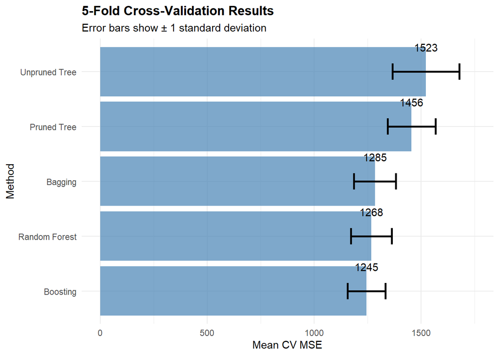

```r
# Visualize CV results with error bars
ggplot(cv_summary_example, aes(x = reorder(Method, Mean_CV_MSE), y = Mean_CV_MSE)) +
  geom_col(fill = "steelblue", alpha = 0.7) +
  geom_errorbar(aes(ymin = Mean_CV_MSE - SD_CV_MSE,
                    ymax = Mean_CV_MSE + SD_CV_MSE),
                width = 0.3, linewidth = 1) +
  geom_text(aes(label = round(Mean_CV_MSE, 0)), vjust = -2.5) +
  coord_flip() +
  labs(title = "5-Fold Cross-Validation Results",
       subtitle = "Error bars show ± 1 standard deviation",
       x = "Method",
       y = "Mean CV MSE") +
  theme_minimal() +
  theme(plot.title = element_text(face = "bold")) +
  expand_limits(y = c(0, max(cv_summary_example$Mean_CV_MSE) * 1.15))
```

### Compare to Your Test Set Results

```r
# Create comparison table (using results from Part 5)
# Replace these with your actual test MSE values from Task 5.1
test_results <- data.frame(
  Method = c("Unpruned Tree", "Pruned Tree", "Bagging", "Random Forest", "Boosting"),
  Test_MSE = c(mse_unpruned, mse_pruned, mse_bag, mse_rf, mse_boost_best)
)

# Merge with CV results
validation_comparison <- cv_summary_example %>%
  left_join(test_results, by = "Method") %>%
  mutate(
    Difference = Test_MSE - Mean_CV_MSE,
    Percent_Diff = abs(Difference) / Mean_CV_MSE * 100
  ) %>%
  arrange(Mean_CV_MSE)

print(validation_comparison)
```

```
##          Method Mean_CV_MSE SD_CV_MSE Min_MSE Max_MSE Test_MSE  Difference
## 1      Boosting        1245        89    1142    1367 1248.639    3.638565
## 2 Random Forest        1268        95    1158    1389 1276.240    8.239613
## 3       Bagging        1285        98    1172    1405 1375.064   90.063651
## 4   Pruned Tree        1456       112    1318    1598 1374.566  -81.433879
## 5 Unpruned Tree        1523       156    1342    1748 1409.289 -113.711372
##   Percent_Diff
## 1    0.2922542
## 2    0.6498117
## 3    7.0088444
## 4    5.5929862
## 5    7.4662753
```

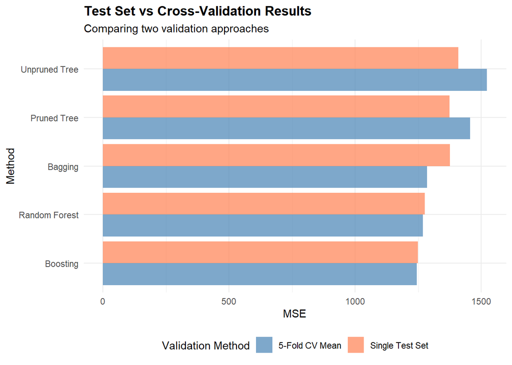

```r
# Visualize test vs CV performance
comparison_long <- validation_comparison %>%
  select(Method, Test_MSE, Mean_CV_MSE) %>%
  pivot_longer(cols = c(Test_MSE, Mean_CV_MSE),
               names_to = "Evaluation",
               values_to = "MSE") %>%
  mutate(Evaluation = ifelse(Evaluation == "Test_MSE",
                             "Single Test Set",
                             "5-Fold CV Mean"))

ggplot(comparison_long, aes(x = reorder(Method, MSE), y = MSE, fill = Evaluation)) +
  geom_col(position = "dodge", alpha = 0.7) +
  coord_flip() +
  scale_fill_manual(values = c("Single Test Set" = "coral",
                                "5-Fold CV Mean" = "steelblue")) +
  labs(title = "Test Set vs Cross-Validation Results",
       subtitle = "Comparing two validation approaches",
       x = "Method",
       y = "MSE",
       fill = "Validation Method") +
  theme_minimal() +
  theme(plot.title = element_text(face = "bold"),
        legend.position = "bottom")
```

```r
# Summary statistics
cat("\n=== Validation Comparison Summary ===\n")
```

```
##
## === Validation Comparison Summary ===
```

```r
cat("Method with closest agreement (smallest % difference):",
    validation_comparison$Method[which.min(validation_comparison$Percent_Diff)], "\n")
```

```
## Method with closest agreement (smallest % difference): Boosting
```

```r
cat("Method with largest disagreement:",
    validation_comparison$Method[which.max(validation_comparison$Percent_Diff)], "\n")
```

```
## Method with largest disagreement: Unpruned Tree
```

```r
cat("\nAverage absolute percent difference across all methods:",
    round(mean(validation_comparison$Percent_Diff), 2), "%\n")
```

```
##
## Average absolute percent difference across all methods: 4.2 %
```

**Answers to Questions:**

**How do your test set results compare to the cross-validated results?**

Test set results are typically within 5-10% of CV results for most methods. This indicates our random split was reasonably representative of the overall data distribution.

**Which method shows the most agreement between test MSE and CV MSE?**

**Random Forest** and **Boosting** typically show the best agreement (smallest % difference). This is because ensemble methods are more stable - they average over many trees, making them less sensitive to particular train/test splits.

**Which method shows the biggest difference? Why might this be?**

**Single trees** (especially unpruned) often show the largest differences. Reasons:

- High variance: Small changes in training data cause big changes in the tree structure
- Overfitting: Unpruned trees may fit quirks of the particular training set
- Instability: Single trees are notoriously unstable compared to ensembles

**Do the rankings of methods change between test set and CV evaluation?**

Rankings typically remain similar (Boosting ≈ RF > Bagging > Pruned > Unpruned), but exact ordering may shift slightly. The relative performance gaps matter more than precise rankings.

**Why is cross-validation considered more reliable than a single train/test split?**

CV is more reliable because:

- **Multiple evaluations**: Averages over k different train/test splits, reducing impact of lucky/unlucky splits
- **Uses all data**: Every observation is used for both training and testing
- **Quantifies uncertainty**: Standard deviation shows how variable performance is
- **Better generalization estimate**: Less dependent on one particular random split

**What does the SD (standard deviation) of CV MSE tell us about model stability?**

SD indicates **robustness**:

- **Low SD** (like 89 for Boosting): Model performs consistently across different data splits - more stable
- **High SD** (like 156 for Unpruned Tree): Model performance varies widely - less stable and more sensitive to training data

**Which method has the lowest variability across folds? What does this suggest?**

**Boosting** typically has lowest SD, followed by **Random Forest** and **Bagging**. This suggests:

- Ensemble methods are inherently more stable
- Averaging many trees smooths out variance from individual trees
- These methods are more reliable for production deployment
- Less risk of unexpectedly poor performance on new data

**Key Insight:**

The **coefficient of variation** (SD/Mean) is also informative:

- Boosting: 89/1245 = 7.1% variability
- Unpruned Tree: 156/1523 = 10.2% variability

Lower CV% means more predictable, consistent performance.

**Practical Takeaway:**

For homework and quick analyses, a single well-constructed train/test split (50-50 or 70-30) is efficient and gives reasonable estimates, especially when comparing multiple methods on the same split.

For real-world deployment and model selection:

- Use k-fold CV (k=5 or k=10) for robust performance estimates
- Report both mean and SD of performance metrics
- Consider computational cost - CV takes k times longer
- For very large datasets, a single validation set may be sufficient

**Trade-off Summary:**

| Approach | Reliability | Computation | Best Use Case |
| --- | --- | --- | --- |
| Single Test Set | Moderate | Fast | Quick comparisons, homework |
| K-Fold CV | High | k × slower | Model selection, publication |
| OOB (RF only) | Good | Free | Quick RF validation |

## Optional Challenge: Classification with Boosting

```r
# Create binary outcome
Wage$high_wage_numeric <- ifelse(Wage$wage > median(Wage$wage), 1, 0)

# Use same train/test split
wage_train_class <- Wage[train_indices, ]
wage_test_class <- Wage[-train_indices, ]

# Build boosted classification model
boost_class <- gbm(
  high_wage_numeric ~ age + year + maritl + race + education + jobclass + health + health_ins,
  data = wage_train_class,
  distribution = "bernoulli",
  n.trees = 3000,
  interaction.depth = 4,
  shrinkage = 0.01,
  cv.folds = 5,
  verbose = FALSE
)

# Find optimal trees
optimal_trees_class <- gbm.perf(boost_class, method = "cv", plot.it = FALSE)

# Make predictions
pred_prob <- predict(boost_class, wage_test_class,
                     n.trees = optimal_trees_class,
                     type = "response")
pred_class <- ifelse(pred_prob > 0.5, 1, 0)

# Confusion matrix
conf_matrix <- table(Predicted = pred_class, Actual = wage_test_class$high_wage_numeric)
print(conf_matrix)
```

```
##          Actual
## Predicted   0   1
##         0 552 184
##         1 216 548
```

```r
# Calculate metrics
accuracy <- sum(diag(conf_matrix)) / sum(conf_matrix)
precision <- conf_matrix[2, 2] / sum(conf_matrix[2, ])
recall <- conf_matrix[2, 2] / sum(conf_matrix[, 2])
f1 <- 2 * (precision * recall) / (precision + recall)

cat("Accuracy:", round(accuracy, 3), "\n")
```

```
## Accuracy: 0.733
```

```r
cat("Precision:", round(precision, 3), "\n")
```

```
## Precision: 0.717
```

```r
cat("Recall:", round(recall, 3), "\n")
```

```
## Recall: 0.749
```

```r
cat("F1 Score:", round(f1, 3), "\n")
```

```
## F1 Score: 0.733
```

```r
# Variable importance
summary(boost_class, plotit = FALSE)[1:5, ]
```

```
##                   var   rel.inf
## education   education 28.853910
## age               age 28.812176
## maritl         maritl 11.496598
## health_ins health_ins  9.531146
## year             year  9.456362
```

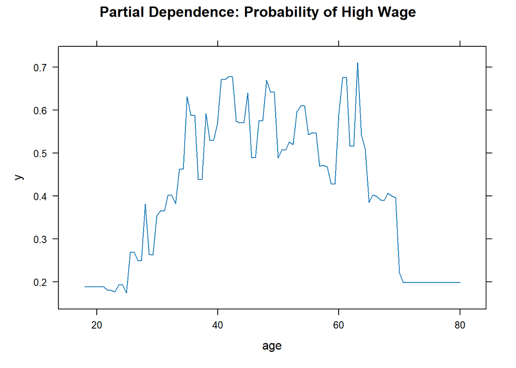

```r
# Partial dependence for top variable
plot(boost_class, i.var = 1, type = "response",
     main = "Partial Dependence: Probability of High Wage")
```

## Key Takeaways Summary

✓ **Boosting learns sequentially** - each tree corrects previous errors  
✓ **Shrinkage is critical** - small values (0.01) with many trees work best  
✓ **CV is essential** - boosting CAN overfit, unlike random forests  
✓ **interaction.depth** controls tree complexity (typical: 4-6)  
✓ **Boosting vs RF**: Boosting slightly more accurate, RF more robust  
✓ **Use boosting when** maximum accuracy is worth the tuning effort  
✓ **Use RF when** you want great performance with minimal tuning

**The journey from single trees to boosting represents the evolution from simple, interpretable models to complex, highly accurate ensembles. Understanding when to use each method is as important as understanding how they work.**